# R Workshop

10/04/2019

# Intro

For today’s workshop, we’re going to use R to go through a typical bioinformatics analysis workflow. We’re going to use common bioinformatics techniques to pre-process and analyze gene expression data related to breast cancer.

The data we will analyze is breast cancer RNA-Seq data from [TCGA](https://www.cancer.gov/about-nci/organization/ccg/research/structural-genomics/tcga), a popular publicly-available database for cancer-related datasets. The goal of the analysis will be to identify genes that show significant changes in expression between normal and tumor tissues, followed by identifying the pathways they are associated with. After importing the data and performing some data pre-processing, we will carry out differntial expression analysis and gene set enrichment analysis.

Main steps in today’s workshop:

1. Import and pre-process RNA-Seq data
2. Identify differentially-expressed genes between tumor and control samples
3. Identify significantly-enriched pathways in the gene sets

Make sure to have the following packages installed for this workshop:

- `Biobase`
- `dplyr`
- `DESeq2`
- `fgsea`
- `ggplot2`
- `msigdbr`
- `fgsea`

# Working with Expression Set Objects

An expression set is a data object consisting of three entities: the expression matrix (`exprs`), the phenotye data (`pData`), and the feature data (`fData`).

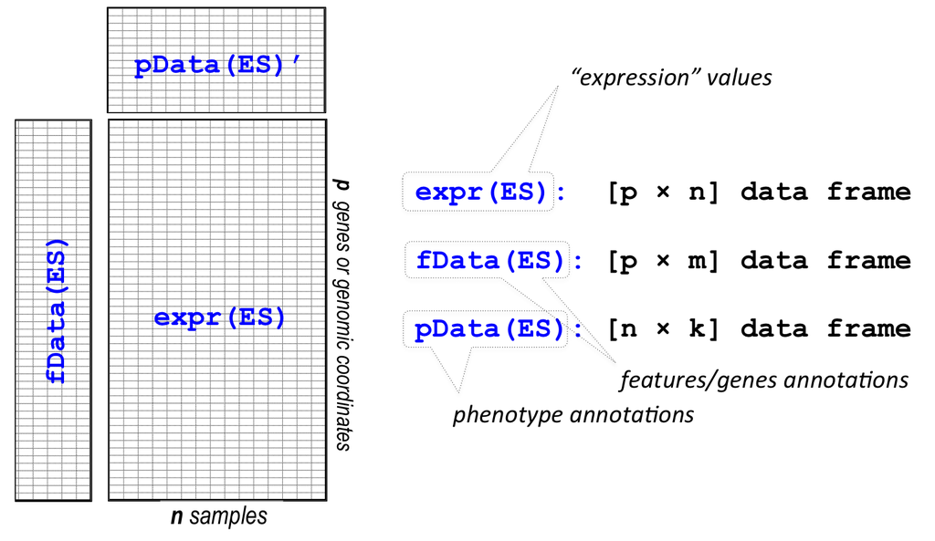

We read in the RDS file included in this repo. It corresponds to a subset of samples from a gene expression dataset of breast cancer (BRCA) primary tissue samples from the TCGA project.

```r
library(Biobase)
library(magrittr)
library(dplyr)
library(ggplot2)
library(DESeq2)
library(fgsea)
```

```r
brca <- readRDS("data/TCGA-BRCA.rds")

# dimensions of the expression data
dim(brca)
```

```
## Features  Samples
##    36812     1222
```

```r
# dimensions of the gene annotation
dim(fData(brca))
```

```
## [1] 36812     4
```

```r
# first few rows of gene annotations
head(fData(brca)[,c("ensembl_transcript_id", "ensembl_gene_id", "hgnc_symbol")])
```

```
##          ensembl_transcript_id ensembl_gene_id hgnc_symbol
## TSPAN6      ENSG00000000003.13 ENSG00000000003      TSPAN6
## TNMD         ENSG00000000005.5 ENSG00000000005        TNMD
## DPM1        ENSG00000000419.11 ENSG00000000419        DPM1
## SCYL3       ENSG00000000457.12 ENSG00000000457       SCYL3
## C1orf112    ENSG00000000460.15 ENSG00000000460    C1orf112
## FGR         ENSG00000000938.11 ENSG00000000938         FGR
```

```r
# dimensions of the phenotypic annotation
dim(pData(brca))
```

```
## [1] 1222   65
```

```r
# first few rows of phenotype
head(pData(brca)[,c("patient_id", "sample_type", "tumor_subtype")])
```

```
##                                patient_id   sample_type tumor_subtype
## TCGA-A8-A085-01A-11R-A00Z-07 TCGA-A8-A085 Primary Tumor          LumB
## TCGA-A2-A0SY-01A-31R-A084-07 TCGA-A2-A0SY Primary Tumor          LumA
## TCGA-AR-A24Z-01A-11R-A169-07 TCGA-AR-A24Z Primary Tumor          LumB
## TCGA-D8-A1XU-01A-11R-A14M-07 TCGA-D8-A1XU Primary Tumor          LumA
## TCGA-A1-A0SN-01A-11R-A144-07 TCGA-A1-A0SN Primary Tumor          Her2
## TCGA-D8-A73W-01A-22R-A352-07 TCGA-D8-A73W Primary Tumor          LumB
```

```r
# how many of each sample type?
table(pData(brca)$sample_type)
```

```
##
##          Metastatic       Primary Tumor Solid Tissue Normal
##                   7                1102                 113
```

```r
# how many tumor subtypes?
table(pData(brca)$tumor_subtype)
```

```
##
##  Basal   Her2   LumA   LumB Normal
##    169    209    510    198     16
```

One of the advantages of using an ExpressionSet is that the three component objects are always properly paired, and subsetting can be carried out straightforwardly.

```r
#subset first 100 genes and 10 samples
brcaSubset <- brca[1:100,1:10]

#updated dimensions after subsetting
dim(brcaSubset)
```

```
## Features  Samples
##      100       10
```

```r
dim(pData(brcaSubset))
```

```
## [1] 10 65
```

```r
dim(fData(brcaSubset))
```

```
## [1] 100   4
```

# Data Wrangling

This section of the workshop will look at some of the common data pre-processing steps.

### Pre-processing

Do the following:  
1. Extract the phenotype dataframe from the expression set  
2. Filter out “Metastatic” tumors  
3. Keep only “Solid Tissue Normal” samples and “Primary Tumor” samples subtyped as “Basal”  
4. Rename entries in the “sample_type” column as “tumor” and “normal”  
5. Subset the original expression set by the filtered samples  
6. Replace the pData slot with the updated data frame

```r
brca.sub <- ...
```

Your output should have the following dimensions:

```r
dim(brca.sub)
```

```
## Features  Samples
##    36812      282
```

```r
table(brca.sub$sample_type)
```

```
##
## normal  tumor
##    113    169
```

```r
table(brca.sub$tumor_subtype)
```

```
##
## Basal
##   169
```

### Variation Filtering

Filter out genes that have zero variance across samples.

```r
brca.filtered <- ...
```

Your output should have the following dimensions:

```r
dim(brca.filtered)
```

```
## Features  Samples
##    35868      282
```

### Low-Counts Filtering

Filter out genes that have zero counts in at least 1/5 of samples.

```r
brca.filtered <- ...
```

Your output should have the following dimensions:

```r
dim(brca.filtered)
```

```
## Features  Samples
##    27156      282
```

### Log-transformation

Log-transform the counts. (Hint: what is log2(0)?)

```r
brca.filtered.log <- ...
```

Show first 5 rows and 2 samples after log-transformation:

```r
exprs(brca.filtered.log)[1:5,1:2]
```

```
##          TCGA-A2-A3XY-01A-11R-A239-07 TCGA-BH-A1EO-11A-31R-A137-07
## TSPAN6                      11.627990                     12.66089
## TNMD                         7.794416                     11.77602
## DPM1                        12.515207                     11.91139
## SCYL3                       10.861087                     10.27030
## C1orf112                     9.672425                      8.73471
```

# Differential Expression Analysis

Differential expression analysis aims to find genes that show a significant change in expression levels between two conditions. Some of the commonly-used R packages for this analysis include *DESeq2*, *edgeR*, and *limma*. For this workshop, we will use *DESeq2* to identify genes that are differentially-expressed between normal and tumor tissue in our dataset. The [DESeq2 vignette](http://bioconductor.org/packages/devel/bioc/vignettes/DESeq2/inst/doc/DESeq2.html) offers an in-depth tutorial that could be helpful for completing this section of the workshop.

### Set up DESeq2 object

The first step is to create a `DESeqDataSet` object. This object includes a variable `design` which should be set to the variables that will be used in the model (e.g. variable to compare, confounding factors). Note that DESeq2 takes the raw counts matrix (un-normalized, not log-transformed) as input, so use the `brca.filtered` object from the previous section..

Hint: use the `DESeqDataSetFromMatrix` function to set up this object using our filtered counts matrix.

```r
#import package
library(DESeq2)

# Create DESeq2 specific object
dds <- ...
```

### Relevel factors

Before we continue, we should set our normal tissue samples as our reference level for comparison in our differential expression analysis.

Hint: use the `relevel` function.

```r
dds@colData$sample_type <- ...
```

### Run DESeq2

Now we can perform the differential expression test and store the results as a table. The results show us the mean expression of the gene, the log fold change in expression between the two sample types, along with p-values and adjusted p-values (FDR) for each gene.

```r
# Run DESeq2
dds <- ...

# Store results in separate variable
res <- ...
```

First few rows of results should look like this:

```
## log2 fold change (MLE): sample type tumor vs normal
## Wald test p-value: sample type tumor vs normal
## DataFrame with 6 rows and 6 columns
##                  baseMean      log2FoldChange             lfcSE
##                 <numeric>           <numeric>         <numeric>
## TSPAN6   3985.45498276106  -0.275207690757347 0.140231733680561
## TNMD     344.547079510424     -4.914680876537  0.40276747216189
## DPM1     2341.91804279032   0.670665650824789 0.103214448542357
## SCYL3    1456.61788705759 -0.0480253193018062 0.120295314682055
## C1orf112 869.504146090585    1.93892739889423 0.138841184009251
## FGR      679.512172461528  -0.396187044121731 0.218117314455008
##                        stat               pvalue                 padj
##                   <numeric>            <numeric>            <numeric>
## TSPAN6    -1.96252077567731   0.0497018842377082   0.0671647084293354
## TNMD      -12.2022785260116 3.02246154511857e-34 5.21114059503202e-33
## DPM1       6.49778844237649 8.15093140726479e-11   2.911046931166e-10
## SCYL3    -0.399228510509649    0.689724837494869    0.726026144731441
## C1orf112   13.9650739276686 2.54641089775556e-44  6.0628830898942e-43
## FGR       -1.81639428814559   0.0693099107632679   0.0904829122235874
```

### MA Plot

DESeq2 contains a function `plotMA` that generates an MA Plot commonly used to visualize the differential expression results. The plot shows the log2 fold changes of a given variable over the mean of normalized counts for all the samples. Points represent genes and will be colored red if the adjusted p-value is less than 0.1. Points which fall out of the window are plotted as open triangles pointing either up or down.

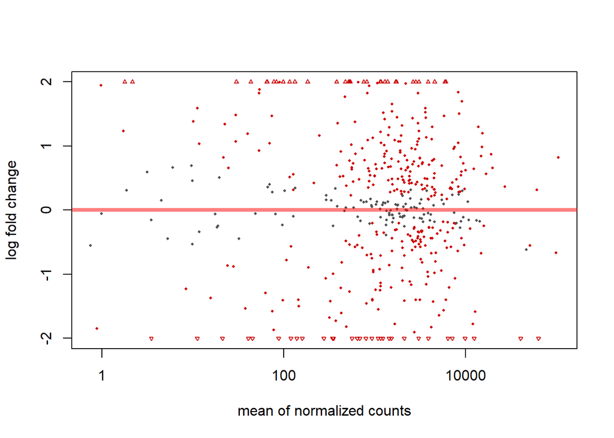

```r
plotMA(res, ylim=c(-2,2))
```

### Significant genes

Let’s add a column that tell us whether each gene shows significant log fold change between tissues. We can add a column showing the significance based on a cutoff value of padj < 0.05.

Hint: convert the results table to a data frame first.

```r
# Convert 'res' to data frame
res <- ...

# Add column with significant genes
res$sig <- ...

# Check first few genes after adding significance column
head(res)
```

```
##           baseMean log2FoldChange     lfcSE        stat       pvalue
## TSPAN6   3985.4550    -0.27520769 0.1402317  -1.9625208 4.970188e-02
## TNMD      344.5471    -4.91468088 0.4027675 -12.2022785 3.022462e-34
## DPM1     2341.9180     0.67066565 0.1032144   6.4977884 8.150931e-11
## SCYL3    1456.6179    -0.04802532 0.1202953  -0.3992285 6.897248e-01
## C1orf112  869.5041     1.93892740 0.1388412  13.9650739 2.546411e-44
## FGR       679.5122    -0.39618704 0.2181173  -1.8163943 6.930991e-02
##                  padj   sig
## TSPAN6   6.716471e-02 FALSE
## TNMD     5.211141e-33  TRUE
## DPM1     2.911047e-10  TRUE
## SCYL3    7.260261e-01 FALSE
## C1orf112 6.062883e-43  TRUE
## FGR      9.048291e-02 FALSE
```

### Volcano plot

Volcano plots are another common way to visualize differential expression results. It shows the log2 fold change on the x-axis and the log10-transformed adjusted p-value on the y-axis (`-1*log10(padj)`), with the points colored according to whether they are significant or not. We can use `ggplot` to create a volcano plot for our results.

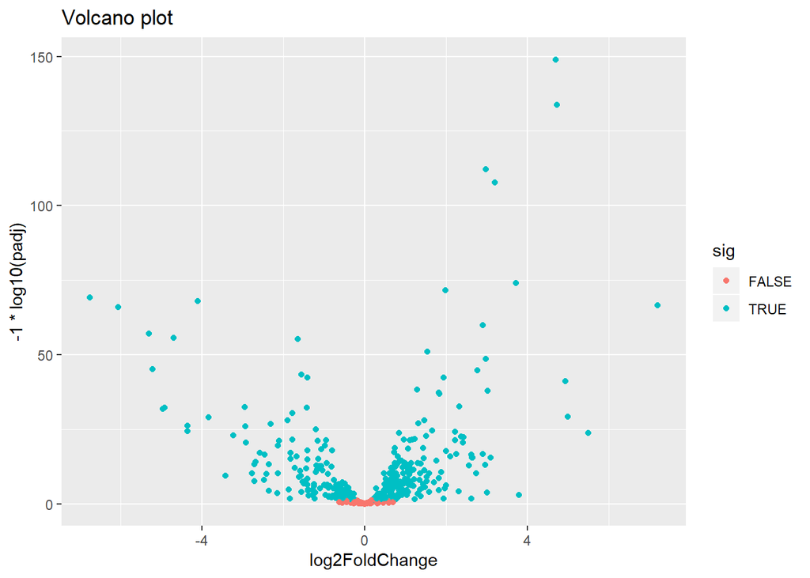

```r
# Volcano plot
ggplot(res, aes(log2FoldChange, -1*log10(padj), col=sig)) +
  geom_point() +
  ggtitle("Volcano plot")
```

# Gene Set Enrichment Analysis

Although we’ve identified differentially expressed genes, we don’t yet know whether the genes have an unifying biological connection. That’s where gene set enrichment analysis (GSEA) comes in. GSEA is a method to identify classes of gene that are over-represented in a large gene set. The calculated enrichment score (ES) reflects the degree to which a gene set is over-represented at the extremes (top or bottom) of the entire ranked list.

GSEA requires two inputs: 1) ranked list of genes of interest - We will be using our differentially expressed genes, ranked by their log2 fold change. 2) gene sets of biological pathways - A gene set should consist of all genes that are biological related or part of the same biological pathway. We can obtain these gene sets from the Molecular Signatures Database (MSigDB).

```r
library(msigdbr)
msigdbr_show_species()
```

```
##  [1] "Bos taurus"               "Caenorhabditis elegans"
##  [3] "Canis lupus familiaris"   "Danio rerio"
##  [5] "Drosophila melanogaster"  "Gallus gallus"
##  [7] "Homo sapiens"             "Mus musculus"
##  [9] "Rattus norvegicus"        "Saccharomyces cerevisiae"
## [11] "Sus scrofa"
```

```r
mdf <- msigdbr(species="Homo sapiens", category="H") %>%
       dplyr::select(gs_name, gene_symbol) %>%
       as.data.frame() %>%
       stats::aggregate(gene_symbol ~ gs_name, data=., c)

# Convert to list
gsets <- as.list(mdf$gene_symbol)
names(gsets) <- mdf$gs_name
```

```r
names(gsets)
```

```
##  [1] "HALLMARK_ADIPOGENESIS"
##  [2] "HALLMARK_ALLOGRAFT_REJECTION"
##  [3] "HALLMARK_ANDROGEN_RESPONSE"
##  [4] "HALLMARK_ANGIOGENESIS"
##  [5] "HALLMARK_APICAL_JUNCTION"
##  [6] "HALLMARK_APICAL_SURFACE"
##  [7] "HALLMARK_APOPTOSIS"
##  [8] "HALLMARK_BILE_ACID_METABOLISM"
##  [9] "HALLMARK_CHOLESTEROL_HOMEOSTASIS"
## [10] "HALLMARK_COAGULATION"
## [11] "HALLMARK_COMPLEMENT"
## [12] "HALLMARK_DNA_REPAIR"
## [13] "HALLMARK_E2F_TARGETS"
## [14] "HALLMARK_EPITHELIAL_MESENCHYMAL_TRANSITION"
## [15] "HALLMARK_ESTROGEN_RESPONSE_EARLY"
```

[output cut: 35 more lines]

```r
head(gsets$HALLMARK_APOPTOSIS)
```

```
## [1] "ADD1"  "AIFM3" "ANKH"  "ANXA1" "APP"   "ATF3"
```

```r
rankedlist <- res[res$sig,'log2FoldChange']
names(rankedlist) <- row.names(res[res$sig,])
rankedlist <- rankedlist[order(rankedlist)]
head(rankedlist)
```

```
##    ATP1A2      FHL1     SCN4A     HSPB6     ABCC8      TNMD
## -6.762690 -6.054090 -5.306231 -5.222524 -4.960307 -4.914681
```

```r
fgseaRes <- fgsea(pathways = gsets,
                  stats = rankedlist,
                  nperm = 10000)
head(fgseaRes[order(pval), ])
```

```
##                            pathway       pval      padj         ES
## 1:             HALLMARK_MYOGENESIS 0.01103247 0.1742090 -0.8544576
## 2:  HALLMARK_XENOBIOTIC_METABOLISM 0.01116394 0.1742090 -0.8185328
## 3:        HALLMARK_APICAL_JUNCTION 0.01463616 0.1742090 -0.7657627
## 4:            HALLMARK_E2F_TARGETS 0.01514861 0.1742090  0.7432472
## 5: HALLMARK_ESTROGEN_RESPONSE_LATE 0.02847641 0.2316455 -0.6224572
## 6:             HALLMARK_PEROXISOME 0.03021463 0.2316455 -0.8551856
##          NES nMoreExtreme size                                 leadingEdge
## 1: -1.658244           52    4                                   FHL1,IGF1
## 2: -1.689623           53    5                       PDK4,IGF1,ELOVL5,CROT
## 3: -1.674946           70    6             CLDN11,CX3CL1,ITGA3,CNTN1,SKAP2
## 4:  1.682179           78    7       DEPDC1,TACC3,HMGB3,NCAPD2,POLA2,BRCA1
## 5: -1.614248          136   11 PRKAR2B,CALCR,ELOVL5,RABEP1,SEMA3B,CACNA2D2
## 6: -1.517626          144    3                                ABCC8,ELOVL5
```

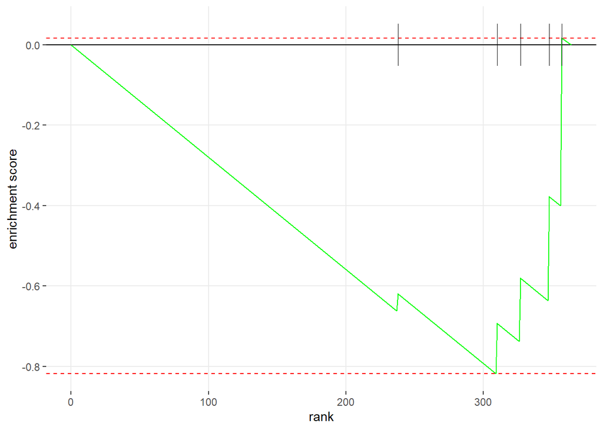

```r
plotEnrichment(gsets$HALLMARK_XENOBIOTIC_METABOLISM,rankedlist)
```

*© The Boys*